# Regresión Logística

Daniel Nájera - A01709578

2024-03-04

# RH - Regresión Logistica

Este documento está dedicado al análisis de diferentes modelos de regresión logistica, aplicados a la **Situación Problema 1: Rotación de Personal**. Utilizamos la base de RH para estos modelos.

La regresión logística es un modelo estadístico utilizado para predecir la probabilidad de un resultado binario o dicotómico, es decir, un resultado que puede tener uno de dos posibles valores, típicamente representados como 0 y 1.

Ventajas:

Es fácil de interpretar en términos de probabilidades. Puede manejar múltiples variables independientes. No requiere que las variables independientes sean linealmente relacionadas con la variable dependiente.

## Librerías Requeridas

```r
# Cargar las librerías necesarias
library(foreign)
library(modelr)
library(dplyr)
library(tidyverse)
library(ggplot2)
library(broom)
library(ISLR)          # great textbook to learn, explore, and put in practice data science skills.
library(readr)
library(caret)
library(e1071)
library(class)
library(ROCR)
library(pROC)
library(lmtest)
library(caTools)
library(rpart)
library(rpart.plot)
library(psych)
library(ggpubr)
library(reshape)
library(Metrics)
library(mlbench)
library(rsample)
library(cluster)     # clustering algorithms
library(factoextra)  # clustering algorithms & visualization
library(gridExtra)
library(ggplot2)
library(zoo)
library(dplyr)
library(modeest)
library(caret)
library(tibble)
library(pROC)
library(randomForest)
library(irr)
library(corrplot)
library(vcd)
library(car)
```

## Bases de Datos Necesarias

**Base de Datos de Bajas - Capital Humano**: Este conjunto de datos ofrece un análisis detallado de los factores demográficos de los empleados. Permite identificar las características personales que pueden influir en la decisión de un empleado de continuar en la empresa o darse de baja.

```r
# Cargar datos
datos <- read.csv("/Users/danielnajera/Downloads/Datos_FORM_RH_FJ2024.csv")
```

```r
str(datos)
```

```
## 'data.frame':    624 obs. of  32 variables:
##  $ No.                        : num  17 30 31 32 28 28 31 21 17 1 ...
##  $ Apellido                   : chr  "ramirez ramirez" "de luna ramos" "contreras lopez" "romero ramirez" ...
##  $ Nombre                     : chr  "sandra luz" "lluvia" "melina sarai" "nayda esmeralda" ...
##  $ Fecha.de.nacimiento        : chr  "1990-02-11" "2002-06-12" "1985-10-12" "1993-10-29" ...
##  $ Género                     : chr  "femenino" "femenino" "femenino" "femenino" ...
##  $ RFC                        : chr  "rars9002117y1" "lurl020612pk7" "colm851012md2" "rorn931029e22" ...
##  $ Fecha.de.Alta              : chr  "2022-08-22" "2023-10-23" "2023-12-01" "2023-12-04" ...
##  $ Primer.Mes                 : chr  NA NA NA NA ...
##  $ Cuarto.Mes                 : chr  "2022-11-20" "2024-01-23" "2024-03-02" "2024-03-05" ...
##  $ Fecha.de.Baja              : chr  NA NA NA NA ...
##  $ Puesto                     : chr  "servicio al cliente" "servicio al cliente" "servicio al cliente" "servicio al cliente" ...
##  $ Dpto                       : chr  "administrativo" "administrativo" "administrativo" "administrativo" ...
##  $ Imss                       : chr  "48119041738" "0 8160235894" "43048514657" "47109358078" ...
##  $ SD                         : num  277 277 277 277 951 ...
```

[output cut: 18 more lines]

## Transformaciones Necesarias

Las transformaciones aplicadas a la base de datos de Capital Humano tienen como objetivo mejorar la interpretabilidad y utilidad de las variables para el análisis. Estas modificaciones son esenciales para adaptar los datos demográficos y de empleo a formatos que faciliten la exploración y el modelado estadístico.

```r
# Cambiar nombres de columnas a camelCase
nuevos_nombres <- names(datos) %>%
  str_replace_all("\\s+", " ") %>%  # Reemplazar múltiples espacios por uno solo
  str_to_lower() %>%               # Convertir todo a minúsculas
  str_replace_all("[^[:alnum:] ]", "") %>%  # Eliminar caracteres no alfanuméricos
  str_replace_all(" ", "") %>%     # Eliminar espacios
  str_replace_all("(?<=[a-z])([A-Z])", "\\1\\2") %>%  # Asegurar camelCase
  make.names()  # Evitar nombres de variables inválidos

names(datos) <- nuevos_nombres
```

```r
str(datos)
```

```
## 'data.frame':    624 obs. of  32 variables:
##  $ no                      : num  17 30 31 32 28 28 31 21 17 1 ...
##  $ apellido                : chr  "ramirez ramirez" "de luna ramos" "contreras lopez" "romero ramirez" ...
##  $ nombre                  : chr  "sandra luz" "lluvia" "melina sarai" "nayda esmeralda" ...
##  $ fechadenacimiento       : chr  "1990-02-11" "2002-06-12" "1985-10-12" "1993-10-29" ...
##  $ género                  : chr  "femenino" "femenino" "femenino" "femenino" ...
##  $ rfc                     : chr  "rars9002117y1" "lurl020612pk7" "colm851012md2" "rorn931029e22" ...
##  $ fechadealta             : chr  "2022-08-22" "2023-10-23" "2023-12-01" "2023-12-04" ...
##  $ primermes               : chr  NA NA NA NA ...
##  $ cuartomes               : chr  "2022-11-20" "2024-01-23" "2024-03-02" "2024-03-05" ...
##  $ fechadebaja             : chr  NA NA NA NA ...
##  $ puesto                  : chr  "servicio al cliente" "servicio al cliente" "servicio al cliente" "servicio al cliente" ...
##  $ dpto                    : chr  "administrativo" "administrativo" "administrativo" "administrativo" ...
##  $ imss                    : chr  "48119041738" "0 8160235894" "43048514657" "47109358078" ...
##  $ sd                      : num  277 277 277 277 951 ...
```

[output cut: 18 more lines]

```r
summary(datos)
```

```
##        no          apellido            nombre          fechadenacimiento
##  Min.   :  1.0   Length:624         Length:624         Length:624
##  1st Qu.:197.7   Class :character   Class :character   Class :character
##  Median :363.5   Mode  :character   Mode  :character   Mode  :character
##  Mean   :363.6
##  3rd Qu.:530.2
##  Max.   :746.0
##     género              rfc            fechadealta         primermes
##  Length:624         Length:624         Length:624         Length:624
##  Class :character   Class :character   Class :character   Class :character
##  Mode  :character   Mode  :character   Mode  :character   Mode  :character
##
##
##
##   cuartomes         fechadebaja           puesto              dpto
##  Length:624         Length:624         Length:624         Length:624
##  Class :character   Class :character   Class :character   Class :character
##  Mode  :character   Mode  :character   Mode  :character   Mode  :character
##
##
##
##      imss                 sd         factordecréditoinfonavit
##  Length:624         Min.   : 144.4   Length:624
##  Class :character   1st Qu.: 217.6   Class :character
##  Mode  :character   Median : 217.6   Mode  :character
##                     Mean   : 228.8
##                     3rd Qu.: 217.6
##                     Max.   :2559.1
##  nodecréditoinfonavit lugardenacimiento      curp              calle
##  Length:624           Length:624         Length:624         Length:624
##  Class :character     Class :character   Class :character   Class :character
##  Mode  :character     Mode  :character   Mode  :character   Mode  :character
##
##
##
##     número            colonia           municipio            estado
##  Length:624         Length:624         Length:624         Length:624
##  Class :character   Class :character   Class :character   Class :character
##  Mode  :character   Mode  :character   Mode  :character   Mode  :character
##
```

[output cut: 8 more lines]

```
##
##  correoelectronico  causadebaja        observacionesdebaja  dirección
##  Length:624         Length:624         Length:624          Length:624
##  Class :character   Class :character   Class :character    Class :character
##  Mode  :character   Mode  :character   Mode  :character    Mode  :character
##
##
##
##    estatus
##  Length:624
##  Class :character
##  Mode  :character
##
##
##
```

Eliminamos los acentos de algunas variables.

```r
names(datos)[names(datos) == "género"] <- "genero"
names(datos)[names(datos) == "factordecréditoinfonavit"] <- "factordecreditoinfonavit"
names(datos)[names(datos) == "dirección"] <- "direccion"
names(datos)[names(datos) == "nodecréditoinfonavit"] <- "nodecreditoinfonavit"
names(datos)[names(datos) == "número"] <- "numero"
names(datos)[names(datos) == "númerodetélefono"] <- "numerodetelefono"
```

Base de Capital Humano

El siguiente bloque de código en R realiza varias transformaciones importantes en la base de datos:

1. **Conversión de Fechas**: Las columnas que contienen fechas se convierten al formato de fecha estándar de R para asegurar que se manejen correctamente como datos temporales.
2. **Extracción de Componentes de Fecha**: Se extraen el mes y el año de nacimiento del empleado a partir de la fecha de nacimiento para análisis específicos relacionados con la temporalidad.
3. **Cálculo de la Edad**: Se calcula la edad del empleado al convertir la diferencia entre la fecha de nacimiento y la fecha actual en años completos.
4. **Cálculo de la Antigüedad**: Se calcula la antigüedad en días, considerando tanto a los empleados activos como a los que ya no están en la empresa, utilizando la fecha de alta y, si está disponible, la fecha de baja.
5. **Mes de Entrada**: Se obtiene el mes de entrada del empleado a la empresa, lo cual es útil para analizar tendencias estacionales en las contrataciones.

```r
datos$fechadenacimiento <- as.Date(datos$fechadenacimiento, format = "%Y-%m-%d")
datos$fechadealta <- as.Date(datos$fechadealta, format = "%Y-%m-%d")
datos$fechadebaja <- as.Date(datos$fechadebaja, format = "%Y-%m-%d")

# Transformar el dataframe
datos <- datos %>%
  mutate(
    Mes_Nacimiento = month(fechadenacimiento),
    Año_Nacimiento = year(fechadenacimiento),

    # Calcular la edad en años utilizando la fecha de nacimiento y la fecha actual
    Edad = as.integer(interval(fechadenacimiento, Sys.Date()) %/% years(1)),
    # Calcular la antigüedad en días directamente
    Antigüedad = as.integer(ifelse(is.na(fechadebaja), Sys.Date() - fechadealta, fechadebaja - fechadealta)),
    Mes_Entrada = if_else(is.na(fechadealta), as.integer(primermes), month(fechadealta))
  )

# Contar cuántos NA hay en cada columna nueva y mostrar los resultados
na_counts <- sapply(datos[c("Mes_Nacimiento", "Año_Nacimiento", "Edad", "Antigüedad", "Mes_Entrada")], function(x) sum(is.na(x)))
print(na_counts)
```

```
## Mes_Nacimiento Año_Nacimiento           Edad     Antigüedad    Mes_Entrada
##              0              0              0              0              0
```

Vamos a convertir variables de caracteres en factores para que podamos mostrar estadísticas descriptivas.

```r
datos$genero<-as.factor(datos$genero)
datos$puesto<-as.factor(datos$puesto)
datos$dpto<-as.factor(datos$dpto)
datos$estado<-as.factor(datos$estado)
datos$estatus<-as.factor(datos$estatus)
datos$estado_civil<-as.factor(datos$estadocivil)
```

```r
na_count <- colSums(is.na(datos))
na_count
```

```
##                       no                 apellido                   nombre
##                        0                        0                        0
##        fechadenacimiento                   genero                      rfc
##                        0                        0                        1
##              fechadealta                primermes                cuartomes
##                        0                       21                        9
##              fechadebaja                   puesto                     dpto
##                      140                        0                        0
##                     imss                       sd factordecreditoinfonavit
##                        1                        0                       58
##     nodecreditoinfonavit        lugardenacimiento                     curp
##                       42                       17                        0
##                    calle                   numero                  colonia
##                        1                        8                        0
##                municipio                   estado                       cp
##                        0                        0                        4
##              estadocivil         numerodetelefono                    banco
##                        0                       36                       66
##        correoelectronico              causadebaja      observacionesdebaja
##                      464                      382                      567
##                direccion                  estatus           Mes_Nacimiento
##                        0                        0                        0
##           Año_Nacimiento                     Edad               Antigüedad
##                        0                        0                        0
##              Mes_Entrada             estado_civil
##                        0                        0
```

Revisemos la estructura de nuestro conjunto de nuestros datos.

```r
#View(datos)
```

```r
summary(datos)
```

```
##        no          apellido            nombre          fechadenacimiento
##  Min.   :  1.0   Length:624         Length:624         Min.   :1962-12-29
##  1st Qu.:197.7   Class :character   Class :character   1st Qu.:1984-08-11
##  Median :363.5   Mode  :character   Mode  :character   Median :1994-03-22
##  Mean   :363.6                                         Mean   :1991-09-11
##  3rd Qu.:530.2                                         3rd Qu.:2000-06-10
##  Max.   :746.0                                         Max.   :2022-10-31
##
##        genero        rfc             fechadealta          primermes
##  femenino :350   Length:624         Min.   :2017-02-20   Length:624
##  masculino:274   Class :character   1st Qu.:2023-01-05   Class :character
##                  Mode  :character   Median :2023-06-09   Mode  :character
##                                     Mean   :2023-04-07
##                                     3rd Qu.:2023-09-11
##                                     Max.   :2024-03-07
##
##   cuartomes          fechadebaja               puesto                dpto
##  Length:624         Min.   :2022-01-25   ayudante :513   produccion    :485
##  Class :character   1st Qu.:2023-03-13   costurero: 15   materiales    : 20
##  Mode  :character   Median :2023-07-01   operador : 15   paileria      : 20
##                     Mean   :2023-06-12   soldador : 15   administrativo: 19
##                     3rd Qu.:2023-09-08   gestor   : 12   cedis         : 19
##                     Max.   :2024-02-22   asistente:  8   calidad       : 15
##                     NA's   :140          (Other)  : 46   (Other)       : 46
##      imss                 sd         factordecreditoinfonavit
##  Length:624         Min.   : 144.4   Length:624
##  Class :character   1st Qu.: 217.6   Class :character
##  Mode  :character   Median : 217.6   Mode  :character
##                     Mean   : 228.8
##                     3rd Qu.: 217.6
##                     Max.   :2559.1
##
##  nodecreditoinfonavit lugardenacimiento      curp              calle
##  Length:624           Length:624         Length:624         Length:624
##  Class :character     Class :character   Class :character   Class :character
##  Mode  :character     Mode  :character   Mode  :character   Mode  :character
##
##
##
##
```

[output cut: 25 more lines]

```
##  activo:140   Min.   : 1.000   Min.   :1962   Min.   : 1.00   Min.   :-365.0
##  baja  :484   1st Qu.: 4.000   1st Qu.:1984   1st Qu.:23.00   1st Qu.:  13.0
##               Median : 7.000   Median :1994   Median :30.00   Median :  41.5
##               Mean   : 6.901   Mean   :1991   Mean   :32.17   Mean   : 143.3
##               3rd Qu.:10.000   3rd Qu.:2000   3rd Qu.:39.00   3rd Qu.: 159.0
##               Max.   :12.000   Max.   :2022   Max.   :61.00   Max.   :2415.0
##
##   Mes_Entrada          estado_civil
##  Min.   : 1.000   casado     :166
##  1st Qu.: 3.000   divorciado :  2
##  Median : 7.000   soltero    :295
##  Mean   : 6.737   union libre:159
##  3rd Qu.: 9.000   viudo      :  2
##  Max.   :12.000
##
```

## K-MEANS Clustering

K-Means Clustering. El objetivo principal de K-Means Clustering es identificar patrones de datos y agrupar observaciones de datos en diferentes grupos en función de sus similitudes. Vale la pena mencionar que K-Means Clustering es un algoritmo de agrupación no supervisado. También es muy útil cuando se trabaja con un conjunto de datos que no tiene etiquetas.

Exploremos la agrupación de k-medias relacionada con “edad” en años

Cabe mencionar que el análisis de agrupamiento de k-medias solo puede incluir variables cuantitativas.

```r
rh_edad<-datos %>% select(genero,estadocivil,sd,Edad)
```

La normalización de un conjunto de datos (variables cuantitativas) utilizando el valor medio y la desviación estándar se realiza mediante scale()

```r
rh_edad_norm<-scale(rh_edad[3:4])
```

### fviz

Utilizamos la función fviz para ver el diagrama de codo para visualizar el número óptimo de grupos

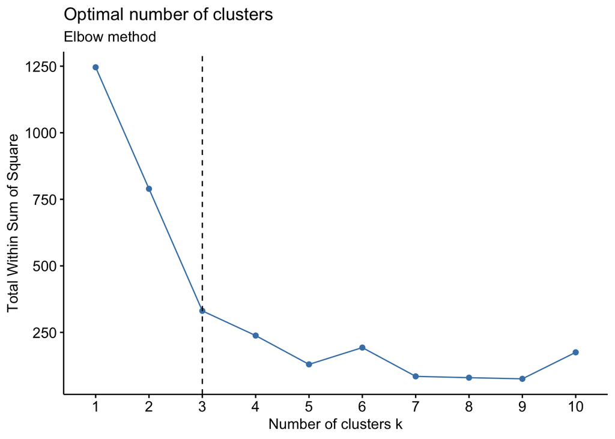

```r
fviz_nbclust(rh_edad_norm, kmeans, method="wss")+ # wss method considers total within sum of square
  geom_vline(xintercept=3, linetype=2)+           # optimal number of clusters is computed with the default method = "euclidean"
  labs(subtitle = "Elbow method")
```

¿Cómo elegir el número adecuado de clusters? La suma de los cuadrados dentro del grupo es un indicador de la dispersión de las observaciones dentro de cada grupo. En términos generales, un grupo con una suma baja de cuadrados es más denso y compacto que un grupo con una suma alta de cuadrados. Normalmente, se selecciona el número ideal de clusters cuando se observa que la SSE empieza a estabilizarse y se forma una curva en codo.

### Agrupado.

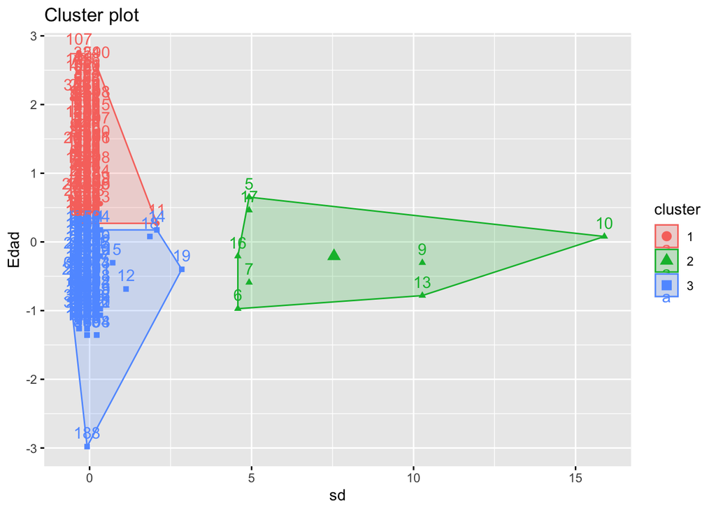

```r
edad_cluster1 <- kmeans(rh_edad_norm, 3)

# Visualizar los clusters
fviz_cluster(edad_cluster1, data = rh_edad_norm)
```

Agreguemos la información de los grupos estimados al conjunto de datos original para que podamos interpretar los resultados.

```r
rh_logistic_alt1<-datos
rh_logistic_alt1$Clusters<-edad_cluster1$cluster
```

Creemos un conjunto de datos para que podamos identificar algunas características de “edad” por grupo.

```r
rh_logistic_alt2<-rh_logistic_alt1 %>% group_by(Clusters) %>% summarise(Edad=max(Edad)) %>% arrange(desc(Edad))
```

Agrupamos los clusters por nombre

```r
rh_logistic_alt1$Cluster_Names<-factor(rh_logistic_alt1$Clusters,levels = c(1,2,3),
                              labels=c("Avanzada","Adulta","Jóven"))
```

Agrupamos los grupos por nombres de grupo y resumir las columnas

```r
rh_logistic_alt3<-rh_logistic_alt1 %>% group_by(Cluster_Names) %>% summarize(edad_años=max(Edad),
                                                             salario=mean(sd),
                                                             Count=n())
```

### Tabla de la agrupación.

Vemos los resultados de la agrupación en la tabla.

```r
clusters<-as.data.frame(rh_logistic_alt3)
clusters
```

```
##   Cluster_Names edad_años   salario Count
## 1      Avanzada        61  214.0657   225
## 2        Adulta        39 1335.2375     8
## 3         Jóven        34  214.7126   391
```

## Regresión logistica.

### Dividir datos en train y test.

```r
set.seed(123) # useful for creating simulations or random objects that can be reproduced
training<-rh_logistic_alt1$Cluster_Names %>%     # training dataset is implemented to build up a model
  createDataPartition(p=0.75,list=FALSE)
train.data<-rh_logistic_alt1[training, ]
test.data<-rh_logistic_alt1[-training, ]
```

### Modelo 1. Regresión logistica simple.

```r
logit_model1<-glm(estatus~sd, data=train.data, family=binomial)
summary(logit_model1)
```

```
##
## Call:
## glm(formula = estatus ~ sd, family = binomial, data = train.data)
##
## Deviance Residuals:
##     Min       1Q   Median       3Q      Max
## -1.7235   0.7228   0.7238   0.7238   0.7254
##
## Coefficients:
##              Estimate Std. Error z value Pr(>|z|)
## (Intercept) 1.190e+00  2.065e-01   5.763 8.26e-09 ***
## sd          7.158e-05  7.656e-04   0.093    0.926
## ---
## Signif. codes:  0 '***' 0.001 '**' 0.01 '*' 0.05 '.' 0.1 ' ' 1
##
## (Dispersion parameter for binomial family taken to be 1)
##
##     Null deviance: 506.16  on 468  degrees of freedom
## Residual deviance: 506.15  on 467  degrees of freedom
## AIC: 510.15
##
## Number of Fisher Scoring iterations: 4
```

```r
contrasts(test.data$estatus)
```

```
##        baja
## activo    0
## baja      1
```

Mostramos las probabilidades de observaciones del conjunto de datos relacionadas con “bajas” y “no bajas”

```r
probabilities<-logit_model1 %>% predict(test.data,type="response")
predicted.classes<-ifelse(probabilities > 0.5, "baja", "no_baja")
head(probabilities)
```

```
##         1         7        13        19        20        27
## 0.7703364 0.7787538 0.7882718 0.7749733 0.7687551 0.7690586
```

```r
head(predicted.classes)
```

```
##      1      7     13     19     20     27
## "baja" "baja" "baja" "baja" "baja" "baja"
```

#### Evaluación del modelo.

Evaluemos la precisión del modelo de regresión logística estimado 1.

```r
test.data$logit_model1_prob <- predict(logit_model1, test.data, type="response")

test.data <- test.data  %>% mutate(logit_model1_pred = 1*(logit_model1_prob > .50) + 0,
                         bajas_binary_1 = 1*(estatus == "baja") + 0)

test.data <- test.data %>% mutate(accurate_1=1*(logit_model1_pred == bajas_binary_1))
sum(test.data$accurate_1)/nrow(test.data)
```

```
## [1] 0.7935484
```

Gráfico de regresión logística que muestra una curva en forma de S.

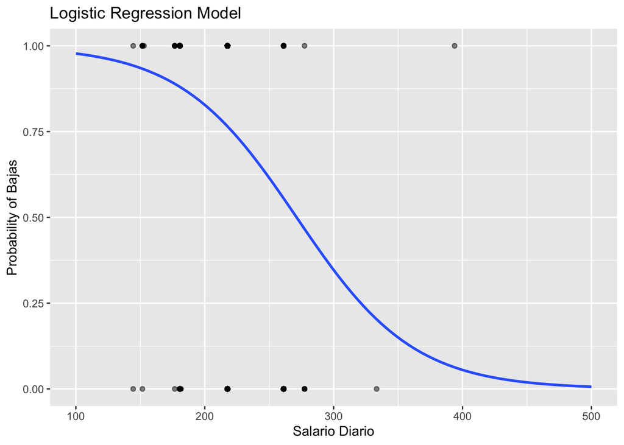

```r
ggplot(rh_logistic_alt1,aes(x=sd, y=as.numeric(estatus)-1)) +
  geom_point(alpha=.5) +
  stat_smooth(method="glm", se=FALSE, fullrange=TRUE, method.args=list(family=binomial)) +
  ylab("Probability") + xlim(100,500)+
  labs(
    title = "Logistic Regression Model",
    x = "Salario Diario",
    y = "Probability of Bajas"
  )
```

##### Matriz de confusión.

```r
prediccion_rl1 <- predict(logit_model1, test.data, type = "response")

confusion_rl1 <- confusionMatrix(as.factor(ifelse(prediccion_rl1>0.6, "baja", "activo")), test.data$estatus, positive = "activo")
confusion_rl1
```

```
## Confusion Matrix and Statistics
##
##           Reference
## Prediction activo baja
##     activo      0    0
##     baja       32  123
##
##                Accuracy : 0.7935
##                  95% CI : (0.7212, 0.8543)
##     No Information Rate : 0.7935
##     P-Value [Acc > NIR] : 0.5471
##
##                   Kappa : 0
##
##  Mcnemar's Test P-Value : 4.251e-08
##
##             Sensitivity : 0.0000
##             Specificity : 1.0000
##          Pos Pred Value :    NaN
##          Neg Pred Value : 0.7935
##              Prevalence : 0.2065
##          Detection Rate : 0.0000
##    Detection Prevalence : 0.0000
##       Balanced Accuracy : 0.5000
##
##        'Positive' Class : activo
##
```

##### AIC.

```r
AIC(logit_model1)
```

```
## [1] 510.1462
```

### Modelo 2. Regresión logistica multiple.

```r
logit_model2<-glm(estatus ~ sd + Edad, data=train.data, family=binomial(link='logit'))
summary(logit_model2)
```

```
##
## Call:
## glm(formula = estatus ~ sd + Edad, family = binomial(link = "logit"),
##     data = train.data)
##
## Deviance Residuals:
##     Min       1Q   Median       3Q      Max
## -1.7724   0.6863   0.7035   0.7306   0.8078
##
## Coefficients:
##               Estimate Std. Error z value Pr(>|z|)
## (Intercept)  1.479e+00  3.987e-01   3.709 0.000208 ***
## sd           6.832e-05  7.656e-04   0.089 0.928891
## Edad        -8.829e-03  1.035e-02  -0.853 0.393503
## ---
## Signif. codes:  0 '***' 0.001 '**' 0.01 '*' 0.05 '.' 0.1 ' ' 1
##
## (Dispersion parameter for binomial family taken to be 1)
##
##     Null deviance: 506.16  on 468  degrees of freedom
## Residual deviance: 505.42  on 466  degrees of freedom
## AIC: 511.42
##
## Number of Fisher Scoring iterations: 4
```

#### Evaluación del modelo.

```r
test.data$logit_model2_prob <- predict(logit_model2, test.data, type="response")

test.data <- test.data  %>% mutate(logit_model2_pred = 1*(logit_model2_prob > .50) + 0,
                                   bajas_binary_2 = 1*(estatus == "baja") + 0)

test.data <- test.data %>% mutate(accurate_2=1*(logit_model2_pred == bajas_binary_2))
sum(test.data$accurate_2)/nrow(test.data)
```

```
## [1] 0.7935484
```

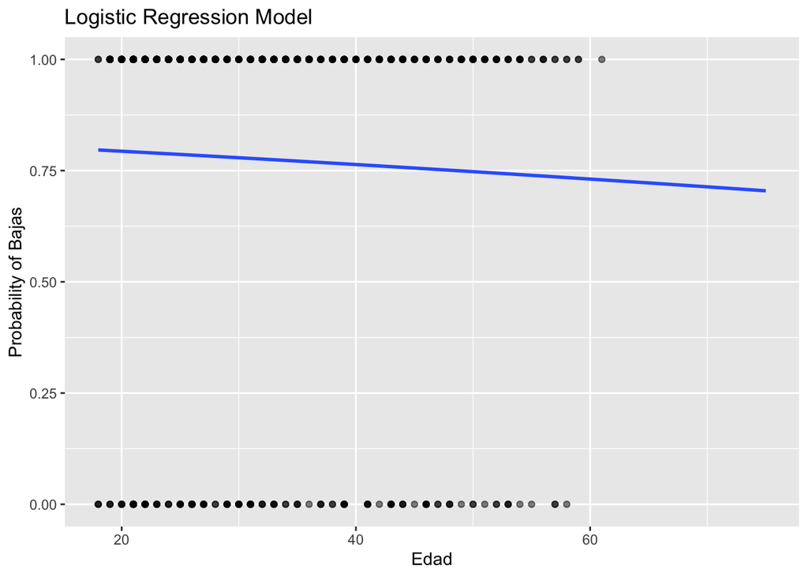

```r
ggplot(rh_logistic_alt1,aes(x=Edad, y=as.numeric(estatus)-1)) +
  geom_point(alpha=.5) +
  stat_smooth(method="glm", se=FALSE, fullrange=TRUE, method.args = list(family=binomial)) +
  ylab("Probability") + xlim(18,75)+
  labs(
    title = "Logistic Regression Model",
    x = "Edad",
    y = "Probability of Bajas"
  )
```

##### Matriz de confusión.

```r
prediccion_rl2 <- predict(logit_model2, test.data, type = "response")

confusion_rl2 <- confusionMatrix(as.factor(ifelse(prediccion_rl2>0.6, "baja", "activo")), test.data$estatus, positive = "activo")
confusion_rl2
```

```
## Confusion Matrix and Statistics
##
##           Reference
## Prediction activo baja
##     activo      0    0
##     baja       32  123
##
##                Accuracy : 0.7935
##                  95% CI : (0.7212, 0.8543)
##     No Information Rate : 0.7935
##     P-Value [Acc > NIR] : 0.5471
##
##                   Kappa : 0
##
##  Mcnemar's Test P-Value : 4.251e-08
##
##             Sensitivity : 0.0000
##             Specificity : 1.0000
##          Pos Pred Value :    NaN
##          Neg Pred Value : 0.7935
##              Prevalence : 0.2065
##          Detection Rate : 0.0000
##    Detection Prevalence : 0.0000
##       Balanced Accuracy : 0.5000
##
##        'Positive' Class : activo
##
```

##### Diagnóstico del Modelo.

```r
vif(logit_model2)
```

```
##       sd     Edad
## 1.000049 1.000049
```

##### AIC.

```r
AIC(logit_model2)
```

```
## [1] 511.424
```

### Modelo 3. Regresión logistica multiple.

Consideremos nuestros resultados estimados del análisis de agrupamiento de K-Means.

```r
logit_model3<-glm(estatus~sd+Cluster_Names, data=train.data, family=binomial(link='logit'))
summary(logit_model3)
```

```
##
## Call:
## glm(formula = estatus ~ sd + Cluster_Names, family = binomial(link = "logit"),
##     data = train.data)
##
## Deviance Residuals:
##    Min      1Q  Median      3Q     Max
## -2.182   0.495   0.714   0.714   2.627
##
## Coefficients:
##                       Estimate Std. Error z value Pr(>|z|)
## (Intercept)           4.205511   0.907205   4.636 3.56e-06 ***
## sd                   -0.014293   0.004094  -3.491 0.000481 ***
## Cluster_NamesAdulta  46.208125 612.643819   0.075 0.939877
## Cluster_NamesJóven    0.142090   0.230945   0.615 0.538388
## ---
## Signif. codes:  0 '***' 0.001 '**' 0.01 '*' 0.05 '.' 0.1 ' ' 1
##
## (Dispersion parameter for binomial family taken to be 1)
##
##     Null deviance: 506.16  on 468  degrees of freedom
## Residual deviance: 484.60  on 465  degrees of freedom
## AIC: 492.6
##
## Number of Fisher Scoring iterations: 15
```

#### Evaluación del modelo.

```r
test.data$logit_model3_prob <- predict(logit_model3, test.data, type="response")

test.data <- test.data  %>% mutate(logit_model3_pred = 1*(logit_model3_prob > .50) + 0,
                                   bajas_binary_3 = 1*(estatus == "baja") + 0)

test.data <- test.data %>% mutate(accurate_3=1*(logit_model3_pred == bajas_binary_3))
sum(test.data$accurate_3)/nrow(test.data)
```

```
## [1] 0.7870968
```

##### Diagnóstico del Modelo.

```r
vif(logit_model3)
```

```
##                   GVIF Df GVIF^(1/(2*Df))
## sd            1.000412  1        1.000206
## Cluster_Names 1.000412  2        1.000103
```

##### Matriz de confusión.

```r
prediccion_rl3 <- predict(logit_model3, test.data, type = "response")

confusion_rl3 <- confusionMatrix(as.factor(ifelse(prediccion_rl3>0.6, "baja", "activo")), test.data$estatus, positive = "activo")
confusion_rl3
```

```
## Confusion Matrix and Statistics
##
##           Reference
## Prediction activo baja
##     activo      1    1
##     baja       31  122
##
##                Accuracy : 0.7935
##                  95% CI : (0.7212, 0.8543)
##     No Information Rate : 0.7935
##     P-Value [Acc > NIR] : 0.5471
##
##                   Kappa : 0.0354
##
##  Mcnemar's Test P-Value : 2.951e-07
##
##             Sensitivity : 0.031250
##             Specificity : 0.991870
##          Pos Pred Value : 0.500000
##          Neg Pred Value : 0.797386
##              Prevalence : 0.206452
##          Detection Rate : 0.006452
##    Detection Prevalence : 0.012903
##       Balanced Accuracy : 0.511560
##
##        'Positive' Class : activo
##
```

##### AIC.

```r
AIC(logit_model3)
```

```
## [1] 492.6004
```

## Referencia.

Thron, James. Logistic Regression Explained. Source: https://towardsdatascience.com/logistic-regression-explained-9ee73cede081